# Quantifying passive kelp rafting phenomena and connectivity of nearshore communities around the coast of South Africa through development of a 3D spectral numerical coastal-flow model

R Coppin[^1]

C Rautenbach[^2]

AJ Smit[^3]

# Summary

Seaweeds are sessile organisms that are unable to migrate to new areas when local environmental conditions become unsuitable and therefore are forced to adapt to new conditions in order to avoid expiration (Dayton 1985; Tegner et al. 1997). The main form of mortality for seaweeds is through mechanical dislodgement by wave action (Schiel et al. 2006; Seymour et al. 1989; Thomsen et al. 2004; Cavanaugh et al. 2011; Graham et al. 1997; Demes et al. 2013; Edwards & Estes 2006). Seaweeds, particularly brown seaweeds, are able to undergo rapid morphological adaptation to the hydrodynamic environment (Miller et al. 2011; Friedland & Denny 1995; Wing et al. 2007; Wernberg & Thomsen 2005; Fowler-Walker et al. 2006; Dudgeon & Johnson 1992; Blanchette et al. 2002). This allows seaweeds to reduce mortality through mechanical dislodgement by inducing morphology which reduces overall drag. Seaweeds that are unable to avoid mechanical dislodgement either raft out to sea or wash up onto beaches. Not all beach-cast kelp may have originated from a nearby kelp population and may have originated from other sites or regions of the coast through rafting and ocean currents (Malm et al. 2004; Emery & Tschudy 1941; Filbee-Dexter & Scheibling 2012; Hobday 2000). Therefore, because kelp morphology is specific to its local environment the morphological features may be able to indicate, within a certain amount of probability, what site or region it most likely originated from. In other words, beach-cast kelp may be used as proxy for investigating the flow of coastal currents. Using kelp as a proxy for determining its original location will be calibrated by means of a hydrodynamic model which will be designed from already existing SWAN and Delft3D models. This combined approach will allow investigation into flow regimes around the west and south-west coasts of South Africa and the role they play in subtidal ecology. Furthermore, the model could be used to determine transport of plastic pollution around the coast. For instance, micro-plastics are recognised as a threat to marine life (Seltenrich 2015; Azzarello & Van Vleet 1987; Wright et al. 2013; Derraik 2002; Andrady 2011; Fendall & Sewell 2009; Ivar Do Sul & Costa 2014; O ’donoghue & Marshall n.d.; Ballent et al. 2012), however very little is known about how microplastics may be transported along the coast.

The increased use of plastic in society over the past half century has resulted in large amounts of plastic litter in both the marine and terrestrial environment (Andrady 2011; Wright et al. 2013; Cole et al. 2011). The problems associated with large plastic debris have received attention for many decades, whereas those connected to marine micro-plastics comparatively received very little attention. However, today it has become a prioritized area among political organizations, agencies and NGOs around the world. The micro-plastic debris present in the ocean are derived from marine and terrestrial sources (Derraik 2002; Wright et al. 2013; Cole et al. 2011; Seltenrich 2015), however there is little understanding of how microplastics may be distributed with ocean currents. Therefore, the coupling the adaptability of kelp morphology and the ability to simulate hydrodynamic processes can greatly improve our understanding of transport pathways and likely locations of accumulation. This in turn may inform management decisions with regards to eliminating and managing marine pollution in South Africa.

# Background

Seaweeds, browns in particular, are capable of adapting morphological characteristics to persist in changing and variable ocean environments. Changes in morphology have been shown to alter photosynthetic ability, nutrient uptake, and reduce probability of dislodgement with regards to variation and changes in sea temperature , wave exposure and light availability. Wave exposure has been shown to be an important driver of seaweed morphology, as the main mechanism of seaweed mortality is through the dislodgement. Changing morphology reduces drag and increases the probability of survival. However, locally adapted seaweed may still be dislodged in pulse disturbance events such as storms, and may raft far distances and wash up on beaches. Beach-cast may not always originate from adjacent kelp populations but rather from other regions which the individual is adapted for. Therefore, the kelp morphology may act as a proxy for investigating coastal currents and changes thereof. The advances in ocean hydrodynamic modelling has made great progress and has been applied in a variety of ways. This study will use advances in hydrodynamic modelling in combination with kelp morphological characteristics to investigate coastal currents. Once the model has been established it may be applied in other ways, such as investigating the transport of microplastics along the South African coastline. The harms of microplastics to the marine environment has gained much traction in recent years, but research in South Africa is lacking. The coupling of kelp morphology and the ability to simulate hydrodynamic processes can greatly improve our understanding of transport pathways and likely locations of accumulation. This in turn may inform management decisions with regards to eliminating and managing marine pollution in South Africa.

Pollution is a huge environmental problem that affects both terrestrial and marine ecosystems. Pollution from land enters the sea where it could harm or kill marine organisms or is transported by ocean currents to other coastal areas. In these areas the pollution could re-enter the ocean or be blown by wind into terrestrial ecosystem where it could once again be ingested by organisms causing harm or even death. Pollution is therefore a major threat to the environment and marine organisms. In recent years the effect of microplastics on the ocean has gained much traction with scientists and politicians alike. Microplastics consist of tiny particles of plastic and other pollution and are therefore are difficult to detect. Currently there is no hydrodynamic model that is able to determine dispersion, source and accumulation of microplastics along the South African coastline. Given the significant detrimental effect microplastics play in the ocean, it is important that such a mechanism be developed that will aid in better management of marine pollution in South Africa. Furthermore, this project allows for a multidisciplinary approach to be taken by combining ecology and coastal oceanography.

Abiotic and biotic factors interact in complex ways which indirectly determine behavioral and ecophysiological responses in organisms. For example, when storms or strong currents form in sub-tidal habitats, sea urchins form aggregations in order to reduce overall drag to avoid being swept away by currents. Organisms that are motile my migrate into more environmentally suitable areas when conditions become unfavorable or food sources become depleted. In changing environments migration may also allow organisms to extend their distributions. For example, ocean warming off the coast of Western Australia has allowed tropical fish species to extend their distribution into areas that were previously characterised as temperate reefs. Sessile organisms are unable to migrate into more environmentally suitable areas and are forced to either adapt or suffer expiration. Sessile organisms may respond to changing environmental conditions through changes in physiology. For example, plants may produce heat shock proteins that help buffer the effect of temperature increases. Sessile organisms may also adapt their morphology,in order to persist in changing and harsh environments, such as seaweeds.

Temperature and wave exposure have been shown to be important drivers of seaweed distribution, physiological functioning, ability to recover, population dynamics and morphology. Mechanical forces generated by the hydrodynamic environment, in the form of sudden strong ocean currents or storms, between 10- 20 m s-1 with accelerations of 400 m s-2 (Friedland and Denny 1995) are the biggest threat to kelp survival. Kelps are able to rapidly adapt their morphological characteristics to reduce drag and avoid dislodgement (Blanchette 1997). For example a study by Koehl et al. (2008) showed that transplanted Nereocystis luetkeana plants from a wave sheltered site to a wave exposed site changed their morphology to flat blades and narrow laterals that are less prone to drag forces in 4-5 days. Another study by Fowler-Walker, Wernberg, and Connell (2006) tested for differences in morphology of Ecklonia radiata between wave-sheltered and wave-exposed sites and through a combination of in situ sampling and transplantation of juvenile plants. The results showed that morphology differed between wave-sheltered and wave-exposed sites (thin thallus at sheltered sites and a narrow, thick thallus with a thick stipe at exposed sites), and was consistent with previous studies. Juveniles transplanted into wave exposed sites under went rapid morphological adaptation, whilst the opposite was true for wave-sheltered sites which showed slower morphological adaptation.

Kelp morphology may be distinct to a particular region with a specific hydrodynamic environment and has the ability to raft far distances using coastal currents, and may accumulate as beach-cast in areas far from its original location. Therefore, kelp morphology may be used as a proxy for determining its original location as well as aid in characterising coastal currents. However, this approach must be combined with advances in hydrodynamic modelling for a quantitative outcome.

Advances in numerical modelling has gained much traction in recent years and has been applied in a variety of ways with regards to ecological studies. For example, a study by Wang and Xia (2009) used the Delft3D-Flow model to assess the hydraulic suitability of a stream as a spawning ground for the Chinese Sturgeon (Acipenser sinensis) in the Yangtze River. The authors calculated the horizontal mean velocity which was used to assess the hydraulic environment of spawning ground. The flow field state was determined through model simulation and field-measured data used to validate the model. The results added to existing scientific database for spawning ground hydraulic environmental protection. Different numerical models can often be integrated to model across ecosystem levels. For example a study by Leon et al. (2003) used integrated physical (Delft3D hydrological model) and bio-chemical (Agricultural Non-point Source model) processes models to investigate the possible impact on the Lake Malawi water quality due to management actions performed at the watershed level.

Since wave energy is an important driver in marine ecosystems, particularly kelp, the advances in hydrodynamic modelling offer a new opportunity for multifactorial and quantitative approach to research in marine ecosystems. The Delft3D and SWAN models have been used successfully in previous studies regarding brine plume discharge, impacts of storms, effects of climate change on the hydrological environment etc. The models have not been designed for shallow environments (<6m) and therefore may not be suitable to model coastal hydrological environments. However these models may be adjusted to suit coastal waters if they are combined with a new numerical model which can be calibrated to suit these needs.

Therefore, this study not only enables research into the ecological effects of the hydrological environment on an important habitat-forming organism, it also offers the opportunity to improve on current hydrological numerical models to suit coastal environments. This in turn will allow investigation into the flow and accumulation of microplastics which are regarded as a major threat to marine life. Furthermore, the calibrated model could be applicable to other ecological studies such as dispersal of benthic flora and fauna, climate change studies, forecasting as some examples.

# Kelp environmental drivers

Important environmental drivers of kelp individuals and communities include light, substrata, salinity, sedimentation, nutrients, temperature and wave exposure. Although studies have investigated the effects of these important environmental drivers, the roles these factors play is often difficult to evaluate as such factors may never be fully independent of each other, i.e. environmental factors are to some extent are dependent on one another. Multifactorial studies have attempted to explain combined effects, however these studies are often limited to investigating combination of two or three environmental drivers as inclusion of too many factors can lead to results that are difficult to interpret. Environmental factors are highly variable on temporal and spatial scales and their effects may also be dependent on the life-stage of the organism, adding a further layer of complexity to investigations.

Depth does not affect kelp ecosystems directly, however a change in depth causes fluctuations or changes in other environmental variables such as water motion, light and temperature. Water motion also decreases with depth, and some kelps better suited to deeper environments (*L. pallida*) replace those in the shallows (*E. maxima*) (Dayton 1985; Gerard 1982). The increase in depth can lead to a decrease in sunlight penetration, with some species better adapted for low-light conditions than others, such as (*L. pallida*). Temperature may also change along a depth gradient due to a reduction in sunlight penetration (Dayton 1985; Gerard 1982). Therefore depth does not directly play a role in kelp functioning but may alter more influential factors such as light and water motion.

The morphological adaptation that macroalgae display are driven by site conditions, therefore individuals must be morphologically flexible to persist in stochastic environments. This may be achieved through different strategies and are species-specific, which can be directly attributed the high diversity in morphological characters of algal communities. For example some algae have fronds and others are articulated coralline, and therefore these species would need to adapt their morphology differently in order to persist. In general, flat strap-like blades are common in areas that are exposed to high wave energy, while at protected sites blade morphology is wide and undulated.

# The mechanisms of morphological adaptation

## Waves and macroalgae characteristics

# Ocean and coastal waves

## Introduction

Regardless of the location around the world, waves are a feature of any coastline and the marine environment, and are important manifestations of energy in the ocean. Waves are not the movement of water particles but rather the movement and propagation of energy through the ocean. The source of this energy can be formed locally, such as wind-driven waves, and or from distant locations in the ocean such as storms, know as *swell*. This energy is transferred from deeper water into shallower water where it plays a role in driving complex marine ecosystems as well as shaping the environments that they live in. Energy that is left-over after these processes is transferred into heat energy, and heats up the sand and rocks on which each wave hits. This energy can also be harnessed in simple ways such as a surfer catching a wave, or more complex ways such as capturing energy from the ocean environment for electricity production. However, waves are stochastic in nature and therefore the energy that propagates through the ocean is not always consistent. Therefore, it is often difficult to quantify and predict wave energy in the marine environment. Despite this fact, waves are gaining more recognition for the role they play in shaping coastlines, beaches and hence the communities and organisms that depend on these systems.

Waves manifest themselves in different ways, which is also dependent on the energy creating force, and can be classified into different categories. For instance, “chop” are produced by local winds, while “tsunamis”" are rare waves that are formed during a earthquakes or landslides and can be produced from thousands of kilometers away. Waves in the ocean are known as “swell” and are produced from far distant storms, while the most consistent form of waves that interacts with the coastlines, usually twice a day, are called “tides”. Tides are produced from differences in gravitational forces between the ocean, earth’s crust, sun and the moon. These classifications can be broken down further and will be investigated later in this chapter. The focus of this chapter will be understanding wave theory and how waves form and propagate into shallow-coastal waters. This will be essential to later chapters that aim to model wave energy and calibrate the produced model with biotic variables.

## Generating and restoring forces

Waves are formed due to the constant interaction between two forces, which are known as the “generating force” and the “restoration force”. The generating force is the force which pushes water from one layer up into the other. Layers in the ocean are formed through differences in temperature (thermocline) and salinity (pycnocline) which creates a boundry for wave energy to move along. In other words, waves occur along the boundaries formed in the ocean by various abiotic processes, and therefore density boundaries are essential to the propagation of energy through the ocean.

The generating force and restoring force occur along these boundaries, the generating force pushes water up across ocean boundaries while the restoring force pulls it back to where the boundary was originally, trying to restore the balance in energy. This “tug of war” between the two forces creates an oscillating motion between the boundary layers which acts as a point of disturbance, sending out energy in all directions. The disturbance energy will continue to manifest itself provided the tug and pull between the two forces is occurring. Once the generating force stops, and ultimately the energy from the point of disturbance, the waves dissipate and water restores to its original state. A simple example would be blowing on water in a cup. The blowing of air onto the surface of the water in the cup creates a point of disturbance that pushes the air boundary into the water boundary. The restoring force is the surface tension of the water that is maintained through hydrogen bonds between water molecules. Once blowing on the water in the cup has stopped, the ripples or “waves” in the cup begin to diminish in size until the surface tension returns to its original state. The hydrogen bonds between the water molecules are stronger than the force of gravity, and therefore the force of the surface tension returns the water to its original state. These waves are known as “capillary waves” and is essentially residual energy after the generating source has stopped. The restoring force can also be in the form of gravity and are known as “gravity waves”. Using the same example, if one blows too hard, the water boundary is pushed up into the air boundary, breaking the hydrogen bonds between water molecules which allows gravity to return the water to its original state. All waves in the ocean are either capillary waves or gravity waves, and their classification will be dependent on the restoring force involved.

## Measuring waves

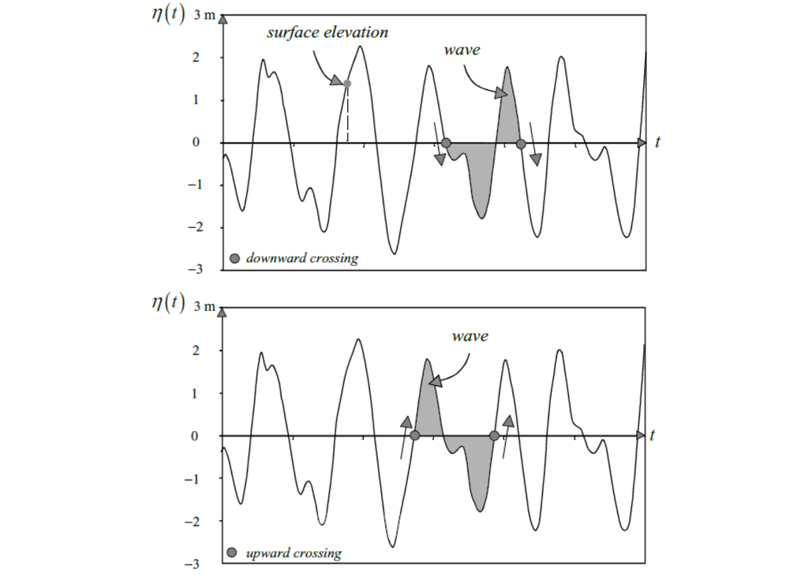

The definition of a wave in a time record of the surface elevation with downward zero-crossings (upper panel) and upward zero-crossings (lower panel).

Characterising waves in a wave record requires compromise both in the statistical sense and the practical, as it is a balance between keeping the record short enough to remain stationary and long enough for a reasonable averages to be calculated. The waves are characterised in terms of wave heights and wave periods for individual waves in the record and then averaged over that specific time. For example, a time record of 15-20 minutes is standard when calculating a wave profile.

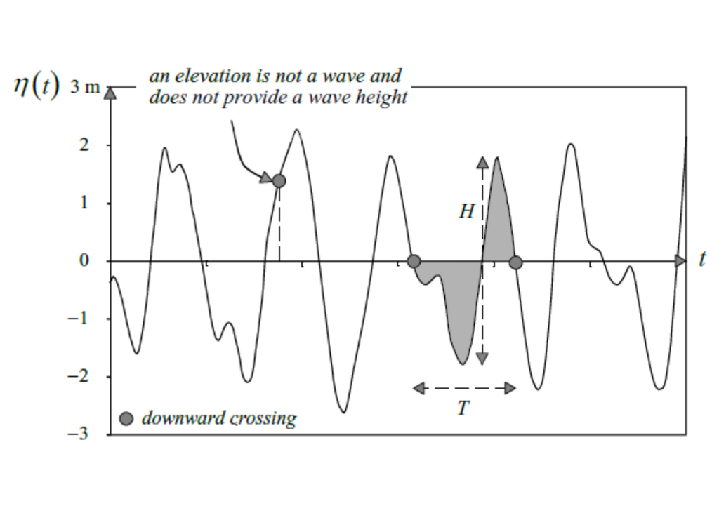

The definition of wave height and wave period in a time record of the surface elevation (the wave is defined with downwrd zero-crossings.

Waves are complex and various approaches, techniques and devices have been developed in order to measure waves effectively. One of the ways that has been used extensively used in the past but less so today, are visual estimates which can be used to characterise *significant swell height* (Hs) and *significant swell period* (Tp). Visual estimates use 15 - 20 of the most well defined, higher waves of a number of wave groups to characterise Hs and Tp. Although these parameters are useful, they do not accurately reflect the waves that are occurring in nature. Ocean waves are a combination of wind sea (short, irregular, locally generated waves) and swell (long, smooth waves, generated by distant storms) and so more parameters are needed to separate Hs and Tp driven by wind sea and swell, i.e. separate Hs and Tp parameters for wind sea and swell. However, even with separate parameters for the different types of waves would still not be enough to effectively characterise waves in the ocean. In order to characterise the detail and complexity of ocean waves a different approach must be used, know as the *spectral* approach. This approach is based on the idea that the sea surface can be characterised as the summation of a large number of harmonic wave components, calculated by the *random-phase/amplitude* model. The random-phase amplitude model is a summation of wave components on a discrete scale, however a continuous scale is more relevant to characterising and measuring of waves in the ocean. The discrete spectrums are converted to continuous spectrums through various arithmetic methods. Therefore, the random-phase amplitude model is used to obtain a *continuous variance density spectrum* which is a statistical relevant measure for scientists and engineers.

# Linear wave theory

# Currents

## Ocean currents

## Nearshore currents

# Ocean modelling

An ocean model is essentially a representation of physical processes in the ocean in the form of equations or computer code which aids in furthering our understanding of how the ocean works. Examples of physical processes include the exchange of energy, mass, and momentum between the ocean and external drivers; ocean movement/dynamics; and 3D mixing and dissipation processes. Examples of process which exchange energy, mass, and momentum between sources include, but are not limited to, radiation, evaporation, precipitation, river runoff and wind energy. Ocean movement and dynamics, as the name suggests, refers to processes which determine the movement of water in the ocean, such as horizontal advection and vertical convection. The 3D mixing and dissipation refers to processes that remove energy from the system such as turbulence caused by temperature differences and wind forcing. There are several approaches to modelling the ocean all of which have advantages and limitations. Conceptual or process models are limited in the different processes that can be incorporated into the model and are often regarded as simple, low resolution models. However conceptual or process models make it easier to interpret dynamics and processes in isolation, and can be run parallel to other models, and can accommodate larger simulations compared to more complex models. In essence, conceptual or process models are mathematical tools to aid in contributing to the theory of ocean processes. Another type of approach are Earth System Models of Intermediate Complexity (EMICs), which have a higher resolution and can run for long timescales with relatively low computation cost. These approaches have been used to investigate coupling of climate and abiotic processes, such as ice sheets and carbon feedback loops. Although EMICs incorporate more complexity, these approaches do not accurately reflect natural ocean processes; instead General Circulation Models (GCMs) provide a better description of the ocean. General circulation models are capable of incorporating multiple processes at a higher resolution. Generally speaking, currently GCMs provide the most accurate way of describing natural ocean processes.

Ocean models are popular tools for investigating future climate scenarios, but have a range of applications outside the realm of academia. Ocean models can also be used in operational oceanography in the maritime and shipping industry (now-casts and forecasts), experimental oceanography, and can be used to mechanistically interpret ocean observations. Ocean models are similar to atmospheric models but fundamentally differ in some respects. For example, atmospheric models involve air which is a compressible gas while ocean models involve seawater which is nearly in-compressible. These differences have significant impacts for how aspects of volume, temperature and pressure influence one another. In air, the interplay between these factors is largely linear and well understood, while in the ocean the relationship is non-linear and poorly understood. For ocean models the equation state used is
$$\rho = f(x)TSP$$
where, $\rho$ represents density and is a function of, $T$ temperature, $S$ salinity, and $P$ pressure. Although the equation state is more complex compared to that of air, some aspects are slightly simpler as seawater is in-compressible and therefore the water entering a grid box will be the same as the water exiting a grid box. Another major difference between ocean and atmospheric models is in ocean models salinity must be taken into account, while with atmospheric models humidity is an important factor. Ocean and atmospheric models also differ slighlty in terms of vertical structure i.e. layering. The surface of the ocean is where most heating and coolong occurs which cause the formation of a marine boundry or mixed layer. Below the mixed layer the ocean becomes more stratified which is ideal for determining flow. However, complications arise in the horizonal layer which does not continiously layer like the atmosphere. The horizontal layer in ocean models needs to take into account irregular bathymetry, shape and size of continental shelves/basins. Furthermore, run-off from rivers can cause changes in the density of seawater along the coasts, thereby altering their flow regimes. Therefore, ocean models need to resolve both the vertical and horizontal structuring, particulary along the ocean margins, which can be achieved through selecting the correct horizontal and vertical coordinate systems. Finally, the ocean interior is largely driven by density gradients compared to the atmosphere which is well mixed and so the equalibrium timescales are much slower relative to the atmosphere. For instance, an ocean model can take as long as 1000 years to start from rest.

There are different ‘types’ of irregular grids available such as using triangles meshed together to form a grid instead of rectangles or squares and is known as ‘finite element modelling’. The size of the triangles can be altered to construct a non-uniform horizontal resolution over the computational domain. For example, the model resolution can be finer for coastal regions and coarser resolution for areas in the middle of the ocean that are not of interest. Therefore, irregular grids can be customised according to what the model is attempting to resolve. Furthermore, irregular grids can accuratley represent areas/regions of complex coastal morphology, bathymetery and physical complex nearshore systems. However, finite element modelling is not without its disadvantages, one being that these models struggle to resolve flow driven by geostrophy and advection, both of which are important characteristics of large-scale ocean flow. Issues also arise when modelling regions which vary in terms of viscosity and diffusivity coefficients. In addition, the issues of numerical diffusion in ocean models is compounded by spatially variable advection schemes when using irregular grids, making these issues harder to resolve. In addition, issues arise when trying to match regions of low resolution with regions of high resolution which imposes limitations on how ocean models resolve certain processes. However, irregular grids are common in coastal and estuarine models which need a high resolution of a specific, spatially complex area. Despite the limitations of using irregular grids for large scale ocean modelling, some predict that the challenges will be overcome and the use of regular grids for large scale modelling will become common place. For example, the development of an irregular, adaptive grid which dynamically changes the resolution as a function of flow in time.

In terms of vertical grids, there are also different ‘types’ that can be used, all of which have advantages and limitations. The vertical grid is sometimes reffered to as ‘vertical coordinate system’, and several aspects need to be taken into account when selecting a vertical grid system. For example one needs to take into account that most of the movement in the ocean is driven by movement at the surface, the ocean is strongly stratisfied, flow occurs along density gradients, and complex bathymetry over the computational domain. As mentioned previously, there are variety of vertical coordinate systems to suite a variety of applications with $Z$, $\theta$, and $\rho$ vertical coordinate systems regarded as the most popular. The absolute depth or $Z$-coordinate system is based on a series of depth levels and is easy to setup, is computationally efficient, and produces no pressure gradient errors. In addition, the resolution can be increased for a desired depth by simply reducing the spacing between the depth levels. However, when increasing the resolution along lateral boundaries (e.g. continental slopes) additional grid cells are needed. This leads to a similar problem as horizontal regular grids, where computational resources are wasted on areas which do not need to be resolved. The terrain following or $\theta$-coordinate system is based on *frictional* depth scaled from 0 to 1. For example, a 0.01$\theta$ level is 1% of the depth of the ocean, and 0.99$\theta$ level represents the 99% of the depth of the ocean. The advantage of this approach is the bathymetery is accurately represented, which allows high resolution near the seafloor, regardless of depth or proximity to land. However, a $\theta$-coordinate system does not resolve pressure gradients accurately as well as variable numerical advection schemes. The last popular approach is the isopycnal or density or $\rho$-coordinate system, which defines the grid based on density layers. Density layers are important drivers of flow in the ocean interior, which the $\rho$-coordinate system is able to characterise. The assumption made for this approach is ocean currents generally flow along surfaces of equal density for ocean interiors, meaning the flow is adiabatic. This approach works well for ocean interiors but performs poorly in shallow waters, where there is very little to no stratification in the water column. Therefore, in order for this approach to be applicable the fluid which flow is being resolved must be stratified. Since each of the approaches differ in terms of advantages and limitations, it is not uncommon to use a combination of coordinate systems known as hybrid coordinate systems. The hybrid coordinate system aims to optimise performance by combining the best suited coordinate system for a particular region. An example of a model that uses a hybrid coordinate system is the HYCOM model, which uses a combination of $Z$ coordinates for the surface layer and $\rho$ density in the ocean below. Hybrid coordinate systems allow vertical coordinates to evolve in both temporally and spatially as the depth changes. Although a dynamically optimised coordinate system improves the results of the model, it is done at a high computational cost.

Another important component of an ocean model is the resolution, in other words the size of the grid. Important to note is that the ocean exhibits ‘multiple scale variability’, which refers to the variability in time and length scales of the ocean. For example, vertical turbulent mixing occurs along a different time and length scale compared to the formation of eddies and fronts. The range of time and space scales can be from molecular (mm and seconds) to basin scale (10 000km and 1000 years). Furthermore, some processes are coupled across scales such that large scale processes are coupled with small scale processes, and are known as ‘non-local interactions’. These non-local processes can have significant effects on both macro- and micro-scale components of the ocean. The resolution of a model is generally defined by the ability to permit or resolve eddies (see table below).

[output not shown]

Important to note is that the eddy ‘resolving-model’ does not resolve all eddies, or their assocaited aspects, but is a description of resolving eddies on what is currently known so far.

The parametrisation of processes in a model is another important component which must be accounted for to ensure computational resources are not wasted on processes which are negligible or too complex. In addition, the understanding of some processes include mesoscale eddy effects, dense overflows, submesoscale eddy effects, coastal processes, surface mixed layer process, friction, sub-grid scale mixing and ocean-ice interactions. Finally, the model needs to be validated to ensure it accurately represents a ‘natural’ ocean. Validation can be difficult as many observations are needed and the measurements themselves can be biased depending on the instruments used. Validation of ocean models has improved over the years due to initiatives such as the Argo Float Program. Other examples include satellites which are capable of measuring sea surface temperature, salinity and wind; while *in situ* instruments (buoys, ships, drifters, floats, temperature recorders, weather stations) provide direct measurements for validation purposes.

Ocean modelling is an important tool to help scientists understand how ocean processes are effected by climate change. However, ocean models are not perfect and challenges must be overcome to improve them, such as the effects of the internal wave field, model bias, dynamic ice sheets, mesoscale eddy fields, mixing and modelling drift. Furthermore, ocean modelling has provided a basis and information for the development of other tools such as hydrodynamic and trajectory modelling.